# Prediction Assignment Writeup

yhuai

2018/4/23

## Overview

### Background

Using devices such as Jawbone Up, Nike FuelBand, and Fitbit it is now possible to collect a large amount of data about personal activity relatively inexpensively. These type of devices are part of the quantified self movement – a group of enthusiasts who take measurements about themselves regularly to improve their health, to find patterns in their behavior, or because they are tech geeks. One thing that people regularly do is quantify how much of a particular activity they do, but they rarely quantify how well they do it. In this project, your goal will be to use data from accelerometers on the belt, forearm, arm, and dumbell of 6 participants. They were asked to perform barbell lifts correctly and incorrectly in 5 different ways. More information is available from the website here: http://web.archive.org/web/20161224072740/http:/groupware.les.inf.puc-rio.br/har (see the section on the Weight Lifting Exercise Dataset).

### Data

The training data for this project are available here: https://d396qusza40orc.cloudfront.net/predmachlearn/pml-training.csv

The test data are available here: https://d396qusza40orc.cloudfront.net/predmachlearn/pml-testing.csv

The data for this project come from this source: http://web.archive.org/web/20161224072740/http:/groupware.les.inf.puc-rio.br/har. If you use the document you create for this class for any purpose please cite them as they have been very generous in allowing their data to be used for this kind of assignment.

```r
library(caret);library(randomForest);library(gbm);
```

```r
library(ggplot2);library(corrplot)
```

## Load and Parse data

```r
TrainUrl <- "https://d396qusza40orc.cloudfront.net/predmachlearn/pml-training.csv"
TestUrl  <- "https://d396qusza40orc.cloudfront.net/predmachlearn/pml-testing.csv"
training <- read.csv("pml-training.csv")
testing  <- read.csv("pml-testing.csv")
dim(training);dim(testing)
```

```
## [1] 19622   160
```

```
## [1]  20 160
```

### Remove NA ,nearly zero variance,identification

```r
NZV <- nearZeroVar(training)
training <- training[, -NZV]
testing   <- testing[, -NZV]
dim(training);dim(testing)
```

```
## [1] 19622   100
```

```
## [1]  20 100
```

```r
training <-training[,colSums(is.na(training)) == 0]
testing <-testing[,colSums(is.na(testing)) == 0]
dim(training);dim(testing)
```

```
## [1] 19622    59
```

```
## [1] 20 59
```

```r
head(colnames(training),10)
```

```
##  [1] "X"                    "user_name"            "raw_timestamp_part_1"
##  [4] "raw_timestamp_part_2" "cvtd_timestamp"       "num_window"
##  [7] "roll_belt"            "pitch_belt"           "yaw_belt"
## [10] "total_accel_belt"
```

```r
training <- training[, -(1:7)]
testing  <- testing[, -(1:7)]
dim(training);dim(testing)
```

```
## [1] 19622    52
```

```
## [1] 20 52
```

## Correlation Matrix Visualization

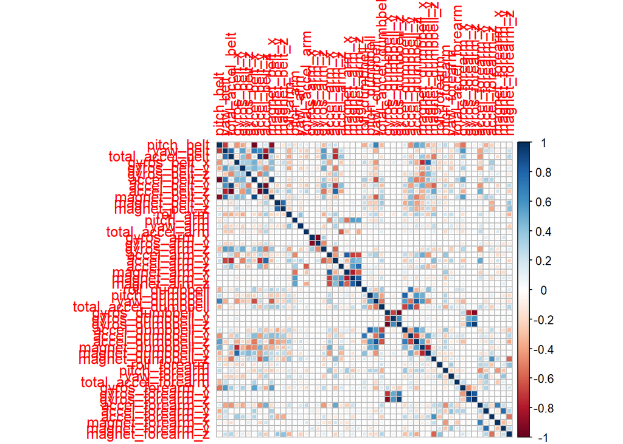

```r
Matrix <- cor(training[, -52])
corrplot(Matrix, method = "square")
```

## Set train and test data

```r
inTrain <- createDataPartition(training$classe,
                               p=0.7,
                               list=FALSE)
train <- training[inTrain,]
test <- training[-inTrain,]
dim(train); dim(test)
```

```
## [1] 13737    52
```

```
## [1] 5885   52
```

## Using different prediction model

```r
set.seed(1993)
fitControl <- trainControl(
    method = "repeatedcv",
    ## 3-fold CV
    number = 3,
    ## repeated 3 times
    repeats = 3)
```

```r
mod_rf <- randomForest(classe ~ . , data=train, ntree=100)
mod_gbm <- train(classe ~ . , data=train, method = "gbm", trControl=fitControl, verbose = FALSE)
mod_lda <- train(classe ~ . , data=train, method = "lda", trControl=fitControl, verbose = FALSE)
```

```r
rfpred <- predict(mod_rf, newdata=test)
gbmpred <- predict(mod_gbm, newdata=test)
ldapred <- predict(mod_lda, newdata=test)
```

```r
confusionMatrix(rfpred, test$classe)$overall['Accuracy']
```

```
##  Accuracy
## 0.9971113
```

```r
confusionMatrix(gbmpred, test$classe)$overall['Accuracy']
```

```
##  Accuracy
## 0.9648258
```

```r
confusionMatrix(ldapred, test$classe)$overall['Accuracy']
```

```
##  Accuracy
## 0.6849618
```

This is model we choose for the further test.

```r
test <- predict(mod_rf, newdata = testing)
test
```

```
##  1  2  3  4  5  6  7  8  9 10 11 12 13 14 15 16 17 18 19 20
##  B  A  B  A  A  E  D  B  A  A  B  C  B  A  E  E  A  B  B  B
## Levels: A B C D E
```